# Python 3 Capstone Assignment

# The Project

1. This is a project with minimal scaffolding. Expect to use the the discussion forums to gain insights! It’s not cheating to ask others for opinions or perspectives!
2. Be inquisitive, try out new things.
3. Use the previous modules for insights into how to complete the functions! You'll have to combine Pillow, OpenCV, and Pytesseract
4. There are hints provided in Coursera, feel free to explore the hints if needed. Each hint provide progressively more details on how to solve the issue. This project is intended to be comprehensive and difficult if you do it without the hints.

### The Assignment

Take a ZIP file) of images and process them, using a [library built into python](https://docs.python.org/3/library/zipfile.html) that you need to learn how to use. A ZIP file takes several different files and compresses them, thus saving space, into one single file. The files in the ZIP file we provide are newspaper images (like you saw in week 3). Your task is to write python code which allows one to search through the images looking for the occurrences of keywords and faces. E.g. if you search for "pizza" it will return a contact sheet of all of the faces which were located on the newspaper page which mentions "pizza". This will test your ability to learn a new ([library](https://docs.python.org/3/library/zipfile.html)), your ability to use OpenCV to detect faces, your ability to use tesseract to do optical character recognition, and your ability to use PIL to composite images together into contact sheets.

Each page of the newspapers is saved as a single PNG image in a file called images.zip. These newspapers are in english, and contain a variety of stories, advertisements and images. Note: This file is fairly large (~200 MB) and may take some time to work with, I would encourage you to use small_img.zip for testing.

Here's an example of the output expected. Using the small_img.zip file, if I search for the string "Christopher" I should see the following image:

[figure not shown]

If I were to use the images.zip file and search for "Mark" I should see the following image (note that there are times when there are no faces on a page, but a word is found!):

[figure not shown]

Note: That big file can take some time to process - for me it took nearly ten minutes! Use the small one for testing.

## Let's Start Coding

```python
import zipfile
import os
from PIL import Image
import pytesseract
import cv2 as cv
import numpy as np
```

### Loading OpenCV Classifier for Face Detection

```python
face_cascade = cv.CascadeClassifier('readonly/haarcascade_frontalface_default.xml')
```

### Function to unZip a Zipfle into a giving directory

```python
def unzipfiles(aZipFile,aDir):
    #Extract files from zipfile local path
    # Hint 1
    aZipRef = zipfile.ZipFile(aZipFile, 'r')
    aZipRef.extractall(aDir)
    aZipRef.close()
```

### Unziping 'small_img.zip' file into 'small_img' directory

```python
#Extracting images in small_img.zip file
imageDirectory = 'small_img'
imZipFile = 'readonly/small_img.zip'
unzipfiles(imZipFile, imageDirectory)
```

### Creating a global Dictionary to store filenames, images and faces

```python
# This will be a dictionary of lists indexed by filename
imagesDir = {}
# [filename][0] : a PIL Image File
# [filename][1] : the Text detecte in the image
# [filename][2] : faces in the image, top and bottom coordinates
```

### A Function to load to load images from a directory and return a list with filenames loaded

```python
def loadImages(aDirectory):
    # Hint 2
    aList = []
    aList = os.listdir(aDirectory)
    aList.sort()
    for aFile in aList:
        imagesDir[aFile] = [Image.open(aDirectory + '/' + aFile)]
    return aList
```

### Let's update the 'filename_list' that needs to be updated

```python
filename_list = [] # list of filenames
filename_list = loadImages(imageDirectory)
```

### Let's search for a word in text and images if word is found

Only if the word is found, the image is analyzed to find faces, faces are 100x100 pixels and contact sheet row max images is 5

```python
def searchWord(aWord):
    for fName in filename_list:
        aImg = imagesDir[fName][0]
        imagesDir[fName].append(pytesseract.image_to_string(aImg).replace('-\n',''))
        # Hint 3
        if aWord in imagesDir[fName][1]:
            print('Results found in file',fName)
            try:
                faces = (face_cascade.detectMultiScale(np.array(aImg),1.28,6)).tolist()
                imagesDir[fName].append(faces)
                facesInfile = []
                for x,y,w,h in imagesDir[fName][2]:
                    facesInfile.append(aImg.crop((x,y,x+w,y+h)))
                contact_sheet = Image.new(aImg.mode, (500,100*int(np.ceil(len(facesInfile)/5))))
                x = 0
                y = 0
                for face in facesInfile:
                    # Hint 4
                    face.thumbnail((100,100))
                    contact_sheet.paste(face, (x, y))
                    if x+100 == contact_sheet.width:
                        x=0
                        y=y+100
                    else:
                        x=x+100
                display(contact_sheet)
            except:
                print('But there were no faces in that file!')
```

### Let's search for the name 'Christopher'

```
Results found in file a-0.png
```

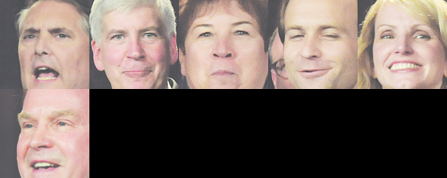

```
Results found in file a-3.png
```

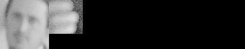

```python
searchWord('Christopher')
```